# Astronaut Dataset Regression

Jeff Shamp

2020-09-03

# Introduction

I have been working on getting up to speed with Tidymodels since it as released last spring. For the fifth and final blog, let’s use tidymodels to compare a few regression models. This data set is from the good people at RStudio and it details space missions from 1960 to 2020. I’ve beeb playing around with to practice cleaning data in addition to modeling with Tidymodels.

Thus is blog post will be part regression analysis and part tidymodel tutorial.

## Astronaut data 1960 - 2020

```r
library(tidyverse)
library(tidymodels)
library(baguette)
```

Load data from the good people at RStudio

```r
astronauts <-
  readr::read_csv('https://raw.githubusercontent.com/rfordatascience/tidytuesday/master/data/2020/2020-07-14/astronauts.csv')
```

Cleaning up the data to isolate the orbiting module.

```r
astronauts<-
  astronauts %>%
  filter(hours_mission > 0 & in_orbit != "explosion") %>%
  select(name, sex, nationality, year_of_birth,
         year_of_selection, year_of_mission,
         military_civilian, occupation, in_orbit,
         hours_mission) %>%
  mutate(occupation = str_to_lower(occupation),
         occupation = case_when(
           str_detect(occupation, "^space  tourist$") ~ "space tourist",
           str_detect(occupation, "space tourist") ~ "space tourist",
           TRUE ~ occupation
            ),
         occupation = str_replace_all(occupation, "other.*", "journalist")) %>%
  mutate(
        in_orbit = str_to_lower(in_orbit),
        in_orbit = str_remove_all(in_orbit, "[:digit:]"),
        in_orbit = str_remove_all(in_orbit, "[:punct:]\\B"),
        in_orbit = case_when(
          str_detect(in_orbit, "^sts") ~ "sts",
          str_detect(in_orbit, "^apollo") ~ "apollo",
          str_detect(in_orbit, "^gemini") ~ "gemini",
          str_detect(in_orbit, "^mir") ~ "mir",
          str_detect(in_orbit, "^salyut") ~ "salyut",
          str_detect(in_orbit, "^saluyt") ~ "salyut",
          str_detect(in_orbit, "^skylab") ~ "skylab",
          str_detect(in_orbit, "^soyuz") ~ "soyuz",
          str_detect(in_orbit, "^ma$") ~ "mercury-atlas",
          TRUE ~ in_orbit)
        ) %>%
  mutate(hours_mission = log(hours_mission)) %>%
  na.omit()
```

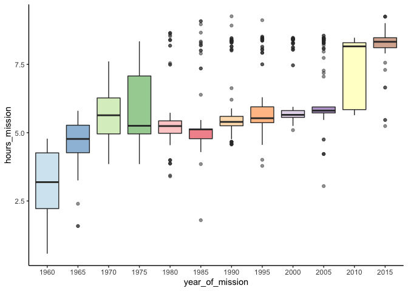

```r
astronauts %>%
  mutate(year_of_mission = case_when(
      year_of_mission < (10*(year_of_mission %/% 10))+5 ~ (10*(year_of_mission %/% 10)),
      year_of_mission >= (10*(year_of_mission %/% 10))+5 ~  (10*(year_of_mission %/% 10))+5,
      TRUE ~ year_of_mission
  ),
  year_of_mission = factor(year_of_mission)) %>%
  ggplot(aes(year_of_mission, hours_mission,
             fill=year_of_mission)) +
  scale_fill_brewer(palette = "Paired") +
  geom_boxplot(alpha=0.5, show.legend = FALSE) +
  theme_classic()
```

## Modeling

Building a regression model based on the selected data. The prediction will be the log of the hours of a given mission.

```r
set.seed(9450)
astro_split<- initial_split(astronauts, strata = hours_mission, prop = .80)
astro_train<- training(astro_split)
astro_test<- testing(astro_split)
```

Creating the recipe will not return the results of the `step_other`, to see and edit the results of that function you have to `prep()` and `juice()` the `astro_recipe`.

```r
astro_recipe<-
  recipe(hours_mission ~ ., data = astro_train) %>%
  update_role(name, nationality, new_role = "ID") %>%
  step_other(occupation, in_orbit, other="Other") %>%
  step_dummy(all_nominal(), -has_role("ID"))

astro_recipe
```

```
## Data Recipe
##
## Inputs:
##
##       role #variables
##         ID          2
##    outcome          1
##  predictor          7
##
## Operations:
##
## Collapsing factor levels for occupation, in_orbit
## Dummy variables from all_nominal, -, has_role("ID")
```

```r
astro_wf<-
  workflow() %>%
  add_recipe(astro_recipe)
```

## Model Types

```r
tree_model<-
  bag_tree() %>%
  set_engine("rpart", times = 30) %>%
  set_mode("regression")

tree_model
```

```
## Bagged Decision Tree Model Specification (regression)
##
## Main Arguments:
##   cost_complexity = 0
##   min_n = 2
##
## Engine-Specific Arguments:
##   times = 30
##
## Computational engine: rpart
```

```r
mars_model<-
  bag_mars() %>%
  set_engine("earth", times=30) %>%
  set_mode("regression")

mars_model
```

```
## Bagged MARS Model Specification (regression)
##
## Engine-Specific Arguments:
##   times = 30
##
## Computational engine: earth
```

```r
ols_model<-
  linear_reg() %>%
  set_engine("lm") %>%
  set_mode("regression")
```

```r
tree_results<-
  astro_wf %>%
  add_model(tree_model) %>%
  fit(astro_train)

mars_results<-
  astro_wf %>%
  add_model(mars_model) %>%
  fit(astro_train)

ols_results<-
  astro_wf %>%
  add_model(ols_model) %>%
  fit(astro_train)
```

We can now make predictions and tie those predictions to the testing dataframe. I like to bind the results back to the data frame so everything is in one place.

```r
test_results<-
  astro_test %>%
  bind_cols(predict(tree_results, astro_test)) %>%
  rename(pred_tree = .pred) %>%
  bind_cols(predict(mars_results, astro_test)) %>%
  rename(pred_mars = .pred) %>%
  bind_cols(predict(ols_results, astro_test)) %>%
  rename(pred_ols = .pred)
```

## Regression Metrics

We will look at RMSE, MAE, and R Square (rsq).

```r
test_results %>%
  metrics(hours_mission, pred_tree)
```

```
## # A tibble: 3 x 3
##   .metric .estimator .estimate
##   <chr>   <chr>          <dbl>
## 1 rmse    standard       0.612
## 2 rsq     standard       0.799
## 3 mae     standard       0.334
```

```r
test_results %>%
  metrics(hours_mission, pred_mars)
```

```
## # A tibble: 3 x 3
##   .metric .estimator .estimate
##   <chr>   <chr>          <dbl>
## 1 rmse    standard       0.605
## 2 rsq     standard       0.802
## 3 mae     standard       0.359
```

```r
test_results %>%
  metrics(hours_mission, pred_ols)
```

```
## # A tibble: 3 x 3
##   .metric .estimator .estimate
##   <chr>   <chr>          <dbl>
## 1 rmse    standard       0.660
## 2 rsq     standard       0.764
## 3 mae     standard       0.394
```